# Homework 3 for Stat 340; Statistical Testing

Karl Rohe

```r
library(dplyr)
library(tidyverse)
```

### 1) Summarize the *How not to be wrong* reading.

1. Give 2-4 sentences summarizing the reading. **First thing that is mentioned is how to prove something wrong by first assuming its correct. In that sense, we can draw logical conclusions from the assumptions, and prove that the conclusion is wrong, hence the initial assumptions is incorrect. Then there is also another way to do this (instead says improbable than impossible, so not as strong of a conclusion) with the reductio ad unlikely. “Either an exceptional rare chance has occurred, or the theory of random distribution is not true”.**
2. Write 2-4 sentences of reaction (question, comments, disagreed, something piqued your interest, etc) on the reading. **I really enjoyed the reading as a whole, as there were cool facts (like how subaru the car manufacturer got its name) across the reading and made it easy to follow. I also liked how their were multiple examples, with clarifications/summaries not too far into the explanation so the reader is still “on the same page” per se. I do wonder, is there anything out there that is considered a closed case that is really more improbably than impossible? like the example with the cluster of stars.**

### 2) Are odd birthdays independent?

1. What does it mean that odd birthdays (as discussed in the text) are independent? Usually, the assumption of independence is about “the real world”. It isn’t “in the data”. It is a “short story” that you need to say about how things could go wrong.

**Odd birthdays being independent means that fi we know some data/set of birthdays, we aren’t able to predict anything about the other birthdays in the data/set. The birthdays have no affect on each other.**

2. The text says that it is **wrong** to assume odd birthdays are independent. Why is that?

**Because of the Power of a test. The more people that are in the same room, the more likely that two people will share the same birthday, but the likelihood is significantly higher. So from this fact, it would not be for certain that odd birthdays are independent.**

3. The text says that it is still **reasonable** to assume odd birthdays are independent. Why is that?

**It’s still reasonable because it isnt a “far-fetched” assumption. When thinking logically initially, it would be reasonable to think that someone being born on an odd birthday would have no affect on someone else also being born on an odd birthday.**

### 3) Green Bay Packers

In last week’s homework, we used Monte Carlo to compute the probability that the Packers would win 13 *or more* games out of 16 under (our best guess of) Olivia Munn’s probability model.

We could imagine this as a statistical hypothesis test. State the null hypothesis and the p-value.

**H0 (null hypothesis): The packers are an average team (50% winning rate)**

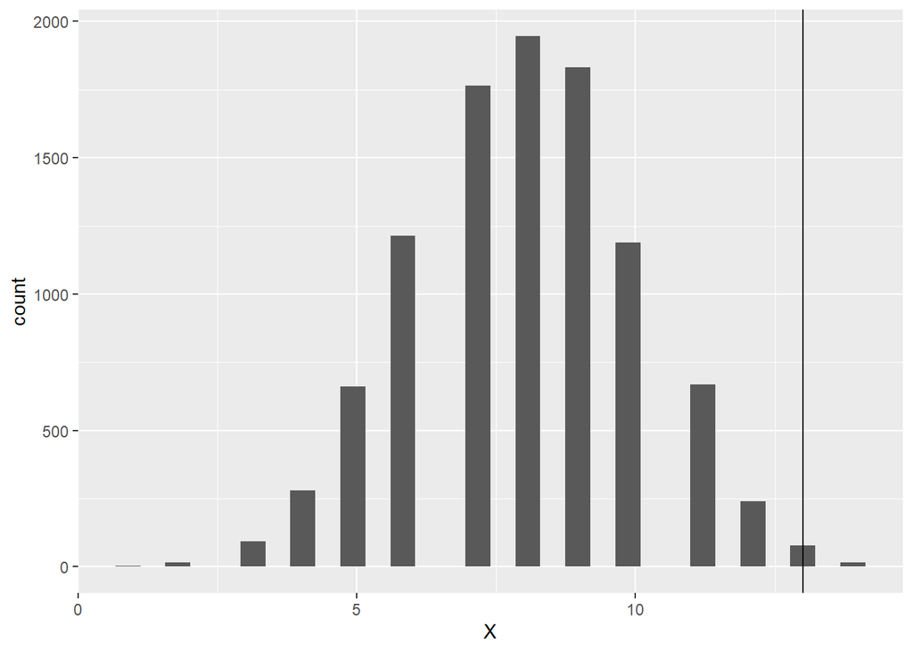

```r
# Copy and paste the code from the top of chapter 2.
# Then, edit the functions simulate_X and check_if_X_in_A

# First, write a function to simulate X
simulate_X = function(){
  return(rbinom(n = 1, size = 16, prob = 0.5))
}

# Second, write a function to evaluate whether X \in A.
check_if_X_in_A = function(X){
  return(X  >= 13)
}

# Now, we are going to do it lots of times.
# Let's arrange the simulations in a data.frame with three columns
r = 10000
monte_carlo = data.frame(replicate = 1:r,
                         X = rep(NA,r),
                         X_in_A = rep(NA, r))
for(i in 1:r){
  monte_carlo$X[i] = simulate_X()
  monte_carlo$X_in_A[i] = check_if_X_in_A(monte_carlo$X[i])
}

monte_carlo = as_tibble(monte_carlo)
p_val = monte_carlo %>% summarise(mean(X_in_A))

ggplot(monte_carlo, aes(x = X)) +
  geom_histogram() +
  geom_vline(xintercept = 13)
```

```r
p_val
```

```
## # A tibble: 1 x 1
##   `mean(X_in_A)`
##            <dbl>
## 1        0.00930
```

**The p-value is < 0.05 (about 0.01) which means we should reject the null hypothesis (that the packers are a so so team). So the packers are better than a so so team.**